# Project 2: Classification

## Task 2: Regression

The following plots were generated using the prediciton_error() function from the yellowbrick library. To read these plots the angle between the best fit and identity lines should be small as possible and the data should hug the identity line very closely. When these two conditions are met it shows that a particular model will have low error and can correctly predict values. For these plots the Random Forest Regressor, KNN regression, and Lasso Regression were used for comparison.

For the Random Forest Regressor we can see that the data does not hug the identify line very closely and that the angle betwee the identity and best fit lines is large. Based on this information we can say that the random forest regressor has slightly higher error and does not predict values very well.

```python
from yellowbrick.regressor import prediction_error

X = X_mtrain_rg
y = y_mtrain_rg.values.ravel()
x_test = X_mtest_rg
y_test = y_mtest_rg.values.ravel()
```

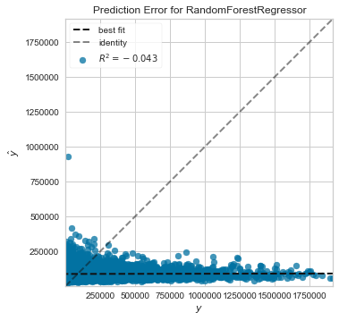

```python
# Instantiate the RF model and visualizer
rf_reg = RandomForestRegressor(bootstrap=True,min_samples_leaf=1, min_samples_split=5,
                               n_estimators=100, n_jobs=-1, oob_score=True, random_state=42)
visualizer = prediction_error(rf_reg, X, y, x_test, y_test)
```

For the KNN Regressor, we can see that the data is widely dispersed and that the best fit and identify lines have a large angle. Of the three regressors, this model preforms the poorest as it has the most error dispite the fact that the angle between the best fit and identity lines are comparable to the Random Forest Regressor.

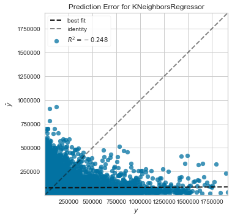

```python
# Instantiate the KNN model and visualizer
knn_reg = KNeighborsRegressor(algorithm='auto', leaf_size=1000, metric='minkowski',
                     n_jobs=-1, n_neighbors=4, p=2, weights='uniform')
visualizer = prediction_error(knn_reg, X, y, x_test, y_test)
```

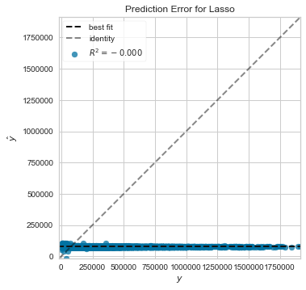

```python
# Instantiate the Lasso model and visualizer
lasso = Lasso(alpha=0.001)
visualizer = prediction_error(lasso, X, y, x_test, y_test)
```

For Task 2, the Lasso regression had the lowest error, but it's predictive ability is not optimal as shown in the prediction_error() plots. This suggests that additional transformation, tunning, or additional data should be used to improve the model's predictive ability. At this time the data has been scaled, PCA has been preformed, and several continuous features were bucketed to create categorical features in attempt to control multi-collinearity and outliers. For future Lasso models, additional features could be engineered, or further transformations could be preformed to improve model preformance.

# Model and Evaluation 5

### Task 1 Classification: Statistical analysis and conclusions

The differences in the three classification models were examined in a statistical sense. Multiple paired t-test were performed using the MTAS scoring metric. We assumed an alpha value of 0.05. For each set of paired models, we found that the p-value was less than the assumed alpha. Thus, in each case we reject the null hypothesis. Model performance between each pair of models is statistically different with p-values ranging from 0.000 to 0.014.

The model with the best MTAS score is Random Forest with 0.732. However, the Random Forest classifier takes significantly longer to run. This is acceptable for a nightly reports or other less frequent uses. The Naïve Bayes classifier does complete quickly and could be used frequently on an as needed basis. As an example, if the business use is an interactive loan questionnaire the Random Forest model would be unsuited due to its’ longer run time, the Naïve Bayes model should be used. However, for overnight reports Random Forest would be preferred.

```python
from mlxtend.evaluate import paired_ttest_5x2cv
from sklearn.ensemble import RandomForestClassifier
from sklearn.linear_model import LogisticRegression

def applyPairedTTest(X, y, model1, model2, scoring):

    t, p = paired_ttest_5x2cv(estimator1=model1,
                              estimator2=model2,
                              X=X, y=y,
                              scoring=scoring, random_seed=42)

    return t, p

# Use the best parameters for each model previouusly identified
#Random Forest
rfc = RandomForestClassifier(max_depth=50, n_jobs=-1, oob_score=True,min_samples_leaf=2,
        min_samples_split=5, n_estimators=200)

# Naive Bayes
nbc = GaussianNB(priors=None, var_smoothing=0.64)

# Logistic Regression
lrc = LogisticRegression(C=1.0, class_weight=None, dual=False, fit_intercept=True,
      intercept_scaling=1, max_iter=100, multi_class='warn',
      n_jobs=None, penalty='l2', random_state=42, solver='liblinear',
      tol=0.0001, verbose=0, warm_start=False)

msMTAS = make_scorer(MTAS)
X = X_mtest_cl
y = y_mtest_cl.values.ravel()

funcResults = []

title = "Random Forest versus Naive Bayes"
t, p = applyPairedTTest(X, y, rfc, nbc, msMTAS)
funcResults.append([title, t, p])

title = "Random Forest versus Logistic Regression"
t, p = applyPairedTTest(X, y, rfc, lrc, msMTAS)
funcResults.append([title, t, p])

title = "Logistic Regression versus Naive Bayes"
t, p = applyPairedTTest(X, y, lrc, nbc, msMTAS)
funcResults.append([title, t, p])

ClassificationResults = pd.DataFrame(funcResults, columns=['Classifiers_to_compare', 't-statistic', 'p-value'])
ClassificationResults
```

|  | Classifiers_to_compare | t-statistic | p-value |
| --- | --- | --- | --- |
| 0 | Random Forest versus Naive Bayes | 36.113498 | 3.064748e-07 |
| 1 | Random Forest versus Logistic Regression | 108.370380 | 1.268688e-09 |
| 2 | Logistic Regression versus Naive Bayes | 3.670803 | 1.443127e-02 |

## Task 1 Classifier ROC Curves

The ROC curves for the Random Forest Classifier show that the model can predict both classes relatively well. This can be seen in the plot below where the curves are near each other and are greater than 95%. We can say that with 95% confidence that the Random Forest Classifier's ability to correctly identify observations based on an F1-sorce has an AUC of at least 95% for both macro and micro calculations for AUC. For AUC calculations micro AUC calculations both response classes are averaged together, and macro AUC calculations are performed by first calculating each response class's individual average followed by an average of each class's average.

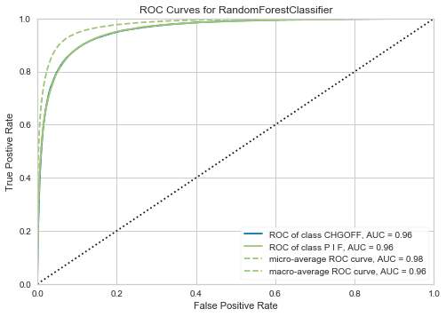

```
ROCAUC(ax=<matplotlib.axes._subplots.AxesSubplot object at 0x000002ED6C0EBD08>,
       classes=['CHGOFF', 'P I F'], encoder=None, force_model=False,
       is_fitted='auto', macro=True, micro=True, model=None, per_class=True)
```

```python
from yellowbrick.classifier.rocauc import roc_auc

X = X_mtrain_cl
y = y_mtrain_cl.values.ravel()
x_test = X_mtest_cl
y_test = y_mtest_cl.values.ravel()

roc_auc(rf_model, X, y, X_test=x_test, y_test=y_test, classes=['CHGOFF', 'P I F'])
```

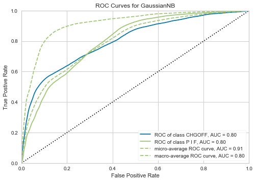

```
ROCAUC(ax=<matplotlib.axes._subplots.AxesSubplot object at 0x000002ED2BBB6588>,
       classes=['CHGOFF', 'P I F'], encoder=None, force_model=False,
       is_fitted='auto', macro=True, micro=True, model=None, per_class=True)
```

```python
X = X_mtrain_cl_npca
y = y_mtrain_cl.values.ravel()
x_test = X_mtest_cl_npca
y_test = y_mtest_cl.values.ravel()

nb_clf = GaussianNB(var_smoothing=0.72)
roc_auc(nb_clf, X, y, X_test=x_test, y_test=y_test, classes=['CHGOFF', 'P I F'])
```

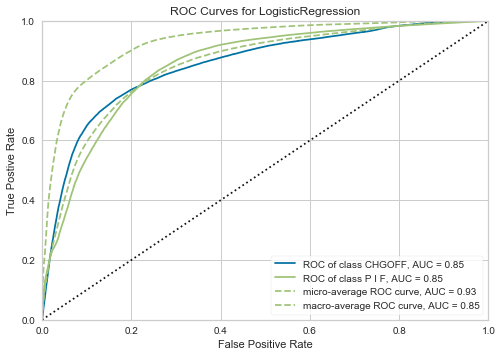

```
ROCAUC(ax=<matplotlib.axes._subplots.AxesSubplot object at 0x000002ED70238288>,
       classes=['CHGOFF', 'P I F'], encoder=None, force_model=False,
       is_fitted='auto', macro=True, micro=True, model=None, per_class=True)
```

```python
x_test = X_mtest_cl
y_test = y_mtest_cl
X = X_mtrain_cl
y = y_mtrain_cl

log_clf = LogisticRegression(C=1.0,n_jobs=-1, random_state=42, solver='liblinear')
roc_auc(log_clf, X, y, X_test=x_test, y_test=y_test, classes=['CHGOFF', 'P I F'])
```

Based on visual inspection of the ROC curves and t-tests for the classifiers, the Random Forest Classifier generates the best AUC values, F1-Scores, and MTAS. A major advantage of this classifier is that this model type is a bagging technique and can create and aggregate many decision trees. This feature of Random Forest Classifiers allows for reduction of overfitting and variance. This classifier is also robust to outliers and can handle missing values.

The major disadvantage for this classifier is the amount of time it took to train the model; for 4-folds it took more than 30 minutes to train compared to at most 10 minutes for a 10-fold grid search resulting in an F1-Score of at least 90%.

### Regression: Statistical analysis and conclusions

The differences in the three classification models were examined in a statistical sense. Multiple paired t-test were performed using the “mean_absolute_error” scoring metric. We assumed an alpha value of 0.05. For each set of paired models, we found that the p-value was less than the assumed alpha. Thus, in each case we reject the null hypothesis. Model performance between each pair of models is statistically different with p-values < 0.000.

The model with the best mean_absolute_error score is lasso/Linear Regression with 73800. However, none of the models showed acceptable predictive power, please see the graphs from section “Model and Evaluation 4”. One or more of the following tasks need to be performed to improve model performance, gather additional data, perform more feature engineering, transform response or explanatory variables, or investigate additional models.

```python
# Evaluate regression tasks
from sklearn.ensemble import RandomForestRegressor
from sklearn.neighbors import KNeighborsRegressor
from sklearn.linear_model import Lasso
import warnings

warnings.filterwarnings('ignore')

rfr = RandomForestRegressor(bootstrap=True, criterion='mse',
                               max_features='auto',min_samples_leaf=1,
                               min_samples_split=5, min_weight_fraction_leaf=0.0,
                               n_estimators=100, n_jobs=-1, oob_score=True,
                               random_state=42, verbose=0, warm_start=False)

knnr = KNeighborsRegressor(algorithm='auto', leaf_size=50, metric='minkowski',
                              metric_params=None, n_jobs=-1, n_neighbors=4, p=2,
                              weights='uniform')

lnr = Lasso(alpha=0.001)

X = X_mtest_rg
y = y_mtest_rg.values.ravel()

funcResults = []
msMAE = make_scorer(mean_absolute_error)

title = "Random Forest Regression versus kNN Regression"
t, p = applyPairedTTest(X, y, rfr, knnr, msMAE)
funcResults.append([title, t, p])

title = "Random Forest Regression versus Linear Regression"
t, p = applyPairedTTest(X, y, rfr, lnr, msMAE)
funcResults.append([title, t, p])

title = "kNN Regression versus Linear Regression"
t, p = applyPairedTTest(X, y, knnr, lnr, msMAE)
funcResults.append([title, t, p])

RegressionResults = pd.DataFrame(funcResults, columns=['Classifiers_to_compare', 't-statistic', 'p-value'])
RegressionResults
```

[output not shown]

# Model and Evaluation 6

The following features are the most important based on yellowbrick's Rank1D Shapiro Ranking plot, and ranking of logistic and Lasso regression weights. The Rank1D ranks features one feature at a time by assesing the normality of the feature's distribution.

**Term** – ranges from 0 months through 539 months. The amount charged off ranged from \$6 - \\$1,618,939. It appears that for loans that were charged off, most charged off early.

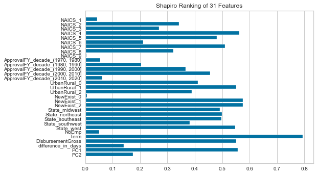

```python
from yellowbrick.features import Rank1D
visualizer = Rank1D(algorithm = 'shapiro')
visualizer.fit(X,y)
visualizer.transform(X)
visualizer.show()
```

**ApprovalFY_1970, 1980** – This is also a significant decade in the dataset becuase this was from 1970 which had its share of presidential and economic events that caused a lot of loans to be charge-off. That could be the reason for a lot of failed loans, but we did not test for that specific reason. We know that from 1970 – 1980 a huge amount of loans failed/charged-off.

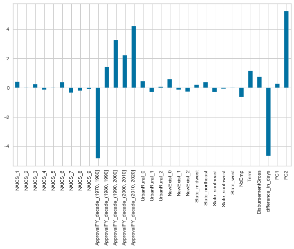

```python
x_test = X_mtest_cl
y_test = y_mtest_cl
X_us2= X_mtrain_cl
y_us2= y_mtrain_cl

log_clf = LogisticRegression(C=1.0,random_state=42, solver='liblinear')

log_clf_fit = log_clf.fit(X_us2,y_us2)

z = pd.Series(log_clf_fit.coef_[0], index=X_us2.columns)
plt.figure(figsize=(10,6))
z.plot(kind='bar')
plt.show()
```

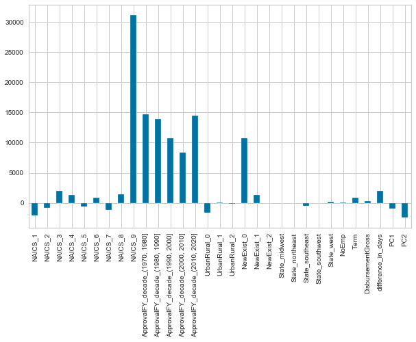

```python
X = X_mtrain_rg
y = y_mtrain_rg.values.ravel()
x_test = X_mtest_rg
y_test = y_mtest_rg.values.ravel()

lasso_reg = Lasso(alpha=0.001)
lasso_fit = lasso_reg.fit(X,y)

w = pd.Series(lasso_fit.coef_,index=X.columns)
plt.figure(figsize=(10,6))
w.plot(kind='bar')
plt.show()
```

# Deployment

The second question we sought to answer concerns the expected default amount for failed loans. Only loans that fail were examined in this section. The models as constructed do not provide acceptable predictive power to answer this question. Additional work will need to be performed to provide an acceptable model. Additional data related to expected sales and revenue would be desirable.

Finally, some consideration must be made of the issues with “Term” and “ChgOffDate”. We attempted to make a charge off rate to handle the problem posed by longer loans having more opportunity to fail simply because they are longer. Unfortunately, the “ChgOffDate” column proved useless to us in establishing a charge off rate. The problem is the “ChgOffDate” is when the loan was formally written off and is in many cases after the normal term of the loan has expired. A better metric might be first late or missed payment. That data is sure to be available within the system and could be used as a substitute for “ChgOffDate” to feature engineer a “LatePaymnetRate” explanatory variable.

# Exceptional Work

We would like to have the following considered for exceptional work:

1. The creation of a gridsearch() helper function that preforms grid-search for hyperparameter tunning, and displays a plot of f1-score per response class; additionally this helper function is able to be used for both regression and classifcation tasks.
2. We have a separate hold-out set for final model testing to prevent "model-doping" or the potenial of mixing training and test data from a standard CV process.
3. Creation of MTAS metric and utilizing make_scorer so that it was accessable to sklearn and mlextend funcitons
4. T-Test for models in addition to ROC curves